# Metody jądrowe (kernel methods)

```python
import numpy as np
import pandas as pd
```

## Duży zbiór danych do klasyfikacji

Użyjemy najpierw bioinformatycznego zbioru danych [Cod-RNA](https://www.csie.ntu.edu.tw/~cjlin/libsvmtools/datasets/binary.html#cod-rna). Pochodzi on z artykułu ([link do wersji Open Access](https://bmcbioinformatics.biomedcentral.com/articles/10.1186/1471-2105-7-173)):

> Uzilov, Andrew V., Joshua M. Keegan, and David H. Mathews. *"Detection of non-coding RNAs on the basis of predicted secondary structure formation free energy change."* BMC bioinformatics 7.1 (2006): 1-30. [link](https://bmcbioinformatics.biomedcentral.com/articles/10.1186/1471-2105-7-173)

[Centralny dogmat biologii molekularnej (central dogma of molecular biology)](https://en.wikipedia.org/wiki/Central_dogma_of_molecular_biology) mówi, że przepływ informacji genetycznej przebiega z DNA przez RNA do białek. Innymi słowy, DNA zapisuje informację biologiczną, którą potem koduje RNA, z którego są syntezowane białka.

W praktyce nie każde DNA i RNA koduje informacje. Kodujące DNA to zaledwie ok. 1-2% ludzkiego genomu, a reszta pełni różne role, głównie regulacyjne. W szczególności [niekodujące RNA (non-coding RNA, ncRNA)](https://en.wikipedia.org/wiki/Non-coding_RNA) pełni wiele różnych zadań, na przykład:

- budują rybosomy odpowiadające za syntezę białek ([rRNA](https://en.wikipedia.org/wiki/Ribosomal_RNA))
- transportują informację genetyczną ([tRNA](https://en.wikipedia.org/wiki/Transfer_RNA))
- regulują ekspresję genów ([lncRNA](https://en.wikipedia.org/wiki/Long_non-coding_RNA))

Nie są znane wszystkie funkcje niekodującego RNA, więc jest to aktywne pole badań. Najpierw trzeba jednak sprawdzić, czy dane RNA w ogóle jest kodujące, czy nie. Taka klasyfikacja jest nieoczywista, i też stanowi pole badań w bioinformatyce. Niektóre hipotezy wskazują, że struktura drugorzędowa RNA ma tutaj znacznie.

Struktura pierwszorzędowa kwasu nukleinowego (DNA lub RNA) to po prostu liniowa sekwencja nukleotydów, np. ACCUUGCAUC. Struktura drugorzędowa oznacza ułożenie par nukleotydów (np. G-C, A-U) jednego lub dwóch łańcuchów. Dla DNA to typowo podwójna helisa, natomiast RNA tworzy już bardzo bogate i złożone struktury. Przewidywanie struktury wyższego rzędu to typowe zadanie ML w bioinformatyce, bo sprawdzanie tego eksperymentalnie jest bardzo drogie.

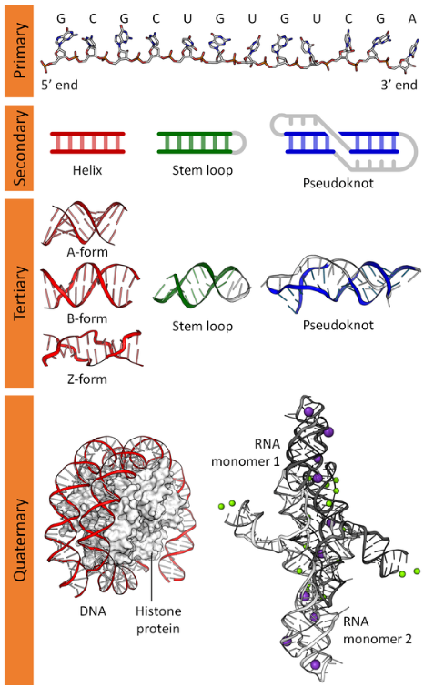

Przykładem algorytmu przewidującego strukturę drugorzędową jest [Dynalign](https://www.sciencedirect.com/science/article/abs/pii/S0022283601953513). Opiera się on na obserwacji, że niektóre struktury drugorzędowe RNA są bardziej stabilne od innych. Struktury o niższej energii są, zgodnie z zasadami termodynamiki, wolniejsze, a zatem stabilniejsze i bardziej prawdopodobne. Algorytm ten dodatkowo realizuje **dopasowanie sekwencji (sequence alignment)**, czyli takie "przyłożenie" do siebie sekwencji RNA, żeby jak najwięcej par pasowało do siebie. Wejściem do niego są 2 sekwencje RNA, a wyjściem ilość wolnej energii w optymalnej strukturze drugorzędowej RNA - im mniejsza, tym stabilniejsza jest struktura.

Artykuł, z którego pochodzi nasz zbiór danych, zaproponował zastosowanie ML do klasyfikacji, czy dwie sekwencje RNA stanowią niekodujące RNA (ncRNA), czy też nie. Zbiór treningowy zbudowano z blisko 60 tysięcy par sekwencji RNA pochodzących z sekwencjonowania genomu bakterii *Escherichia coli* oraz *Salmonella enterica serovar Typhi (Salmonella typhi)*. Klasą pozytywną jest niekodujące RNA (5S rRNA albo tRNA), a negatywną losowo przemieszane nukleotydy z prawdziwej pary (istnieją do tego algorytmy tzw. sequence shuffling). Klasy są w stosunku 1:2, więc mamy klasyfikację lekko niezbalansowaną. Analogicznie stworzono zbiór testowy o wielkości nieco ponad 270 tysięcy par.

Jako cech użyto:

- wartości z algorytmu Dynalign
- długości krótszej sekwencji
- częstotliwości zasad azotowych A/U/C w sekwencji 1 (3 cechy)
- częstotliwości zasad azotowych A/U/C w sekwencji 2 (3 cechy)

Mamy zatem klasyfikację binarną, umiarkowanie niezbalansowaną, i 8 cech numerycznych. Jako metryk autorzy używają precyzji, czułości, krzywych ROC oraz wartości AUROC.

My dla uproszczenia użyjemy F1-score, czyli średniej harmonicznej precyzji (precision) i czułości (recall). Klasyczny SVM nie potrafi przewidywać prawdopodobieństw, a rozwinięcie, które na to pozwala (tzw. Platt scaling), jest kosztowne i daje raczej niskiej jakości predykcje prawdopodobieństw. Z tego powodu AUROC nie jest dla nich zbyt wygodną metryką.

Oryginalny zbiór jest w formacie `svmlight`, z którego korzystają biblioteki LibSVM i Liblinear. Są one standardowymi implementacjami SVMów. Sam ten format danych jest jednak tekstowy i zajmuje bardzo dużo miejsca, dlatego w tym repozytorium jest już przetworzony do formatu Parquet. Wczytamy teraz dane.

Później trzeba dokonać normalizacji cech, tak jak zawsze w SVMach. Tak jak autorzy, wykonamy skalowanie min-max do zakresu [-1, 1].

**Zadanie 1 (0.5 punktu)**

1. Wczytaj dane treningowe z plików `cod_rna_train.parquet` oraz `cod_rna_test.parquet`.
2. Wyodrębnij kolumnę `y` do osobnych zmiennych `y_train` oraz `y_test`.
3. Dokonaj skalowania danych do zakresu [-1, 1], tworząc tablice `X_train_scaled` oraz `X_test_scaled`.
4. Narysuj wykres częstości klas w zbiorze treningowym.

```python
from sklearn.preprocessing import MinMaxScaler


cod_rna_train = pd.read_parquet("cod_rna_train.parquet")
cod_rna_test = pd.read_parquet("cod_rna_test.parquet")

y_train = cod_rna_train.pop("y")
y_test = cod_rna_test.pop("y")

scaler = MinMaxScaler(feature_range=(-1, 1))
X_train_scaled = scaler.fit_transform(cod_rna_train)
X_test_scaled = scaler.transform(cod_rna_test)
```

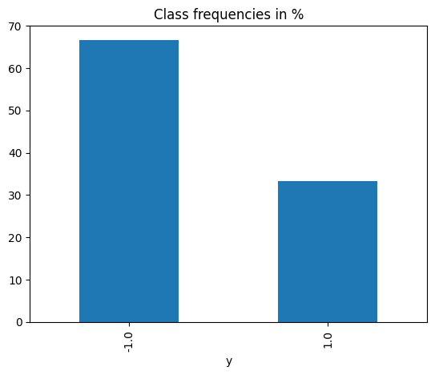

```python
class_frequencies = y_train.value_counts() / y_train.value_counts().sum() * 100
class_frequencies = class_frequencies.sort_index()
ax = class_frequencies.plot.bar()
ax.set_title("Class frequencies in %");
```

Skoro dane są gotowe, to wytrenujmy nasz pierwszy klasyfikator - liniowy SVM.

W Scikit-learn funkcja kosztu (`loss`) to albo typowy hinge loss, albo squared hinge loss, czyli po prostu podniesiona do kwadratu. Wartość domyślna to `"squared_hinge"` - żeby dostać "typowego" SVMa, trzeba to zmienić. Jest różniczkowalna i mocniej kara duże błędy, ale jest też bardziej podatna na outliery. Dla zainteresowanych: [przystępny tutorial](https://github.com/christianversloot/machine-learning-articles/blob/main/how-to-use-hinge-squared-hinge-loss-with-keras.md) oraz artykuł naukowy:

C.P. Lee, and C.J. Lin. *"A study on L2-loss (squared hinge-loss) multiclass SVM."* Neural computation 25.5 (2013): 1302-1323.

Dodatkowo domyślna liczba iteracji solwera (1000) jest często dość niska, szczególnie przy dużych zbiorach. Zwiększymy to od razu, żeby mieć mniej warningów. Powyżej 10 tysięcy iteracji warningami można się już zazwyczaj nie przejmować.

```python
from sklearn.metrics import f1_score
from sklearn.svm import LinearSVC


clf_linear_svc = LinearSVC(loss="hinge", max_iter=10000, random_state=0)
clf_linear_svc.fit(X_train_scaled, y_train)

y_pred = clf_linear_svc.predict(X_test_scaled)
print(f"F1-score: {100 * f1_score(y_test, y_pred):.2f}%")
```

```
F1-score: 93.03%
```

[output not shown]

Mając doświadczenie z zad. 3. z argumentem class_weight="balanced" zobaczmy, jaki f1-score osiąga linearSVC z takim argumentem, bez tuningu C:

```python
# After having done task3 curious to see with class_weigth="balanced"

clf_linear_svc = LinearSVC(
    loss="hinge", max_iter=10000, random_state=0, class_weight="balanced"
)
clf_linear_svc.fit(X_train_scaled, y_train)

y_pred = clf_linear_svc.predict(X_test_scaled)
print(f"F1-score: {100 * f1_score(y_test, y_pred):.2f}%")
```

```
F1-score: 93.24%
```

## Liniowy SVM

**Zadanie 2 (0.5 punktu)**

Wytrenuj regresję logistyczną jako nasz **model baseline'owy**. Nasze bardziej złożone modele SVM muszą być od niego lepsze, żeby był w ogóle sens je rozważać.

Użyj regularyzacji L2. Dokonaj tuningu siły regularyzacji (100 wartości) za pomocą 5-krotnej walidacji skrośnej. Jako metryki do tuningu użyj F1-score.

Użyj zbalansowanych wag klas. W razie potrzeby zwiększ maksymalną liczbę iteracji solwera. Może się przydać `n_jobs`. Pamiętaj o ustawieniu `random_state=0`.

Sprawdź wyniki algorytmu na zbiorze testowym.

##### Logistic Regression pure first

```python
from sklearn.linear_model import LogisticRegression


reg_logistic = LogisticRegression(penalty="l2", random_state=0)
reg_logistic.fit(X_train_scaled, y_train)

y_pred = reg_logistic.predict(X_test_scaled)
f1score = f1_score(y_test, y_pred)

print(f"F1-score: {f1score*100:.2f}%")
```

```
F1-score: 92.48%
```

##### Logistic Regression param tuning

##### Cross-validated Logistic Regression with C tuning L2, tuning scoring="f1"

```python
from sklearn.linear_model import LogisticRegressionCV


reg_logistic_cv = LogisticRegressionCV(
    Cs=100,
    cv=5,
    class_weight="balanced",
    random_state=0,
    n_jobs=-1,
    scoring="f1",
    max_iter=10000,
)
reg_logistic_cv.fit(X_train_scaled, y_train)

y_pred_cv = reg_logistic_cv.predict(X_test_scaled)

f1_score_cv = reg_logistic_cv.score(X_test_scaled, y_test)
print(f"F1-score: {f1_score_cv * 100: .2f}%")
```

```
F1-score:  93.28%
```

##### Cross-validated Logistic Regression with C tuning L2, tuning scoring="f1_weighted"

```python
reg_logistic_cv = LogisticRegressionCV(
    Cs=100,
    cv=5,
    class_weight="balanced",
    random_state=0,
    n_jobs=-1,
    scoring="f1_weighted",
    max_iter=10000,
)
reg_logistic_cv.fit(X_train_scaled, y_train)

y_pred_cv = reg_logistic_cv.predict(X_test_scaled)

f1_score_cv = reg_logistic_cv.score(X_test_scaled, y_test)
print(f"F1-score: {f1_score_cv * 100: .2f}%")
```

```
F1-score:  95.46%
```

Nasz SVM bez żadnego tuningu jest zasadniczo tak dobry, jak regresja logistyczna z tuningiem - całkiem nieźle. No ale czas teraz na tuning samego SVMa.

Najpierw warto wiedzieć jeszcze parę rzeczy o implementacji użytej w Scikit-learn, korzystającej pod spodem z Liblinear.

Argument `dual` wyznacza, czy skorzystać z postaci primal, czy dual. Jeżeli liczba próbek jest znacznie większa od liczby cech, albo ogółem mamy sporo próbek, to lepiej użyć primal `dual=False`. Niestety, wtedy mamy do dyspozycji tylko funkcję kosztu `squared_hinge`.

SVM jest stricte jednowątkowy (sekwencyjny), więc równoległość można wykorzystać przy tuningu hiperparametrów. Zdecydowanie warto użyć tu `n_jobs=-1`.

**Uwaga:** jako że osobne joby są tworzone jako osobne procesy, to wyłączenie `ConvergenceWarning` jest nietrywialne, a czasem niemożliwe. Sugeruję to po prostu zignorować.

**Zadanie 3 (1 punkt)**

Dokonaj tuningu hiperparametru `C` liniowego SVM. Użyj 5-krotnej walidacji skrośnej, wybierając model o najwyższym F1-score. Użyj zbalansowanych wag klas i funkcji kosztu hinge loss. Pamiętaj o stałym `random_state`.

Zastosuj iteracyjne zagęszczanie siatki. Najpierw sprawdź wartości z zakresu `[1e-3, 1e-2, 1e-1, 1, 1e1, 1e2]` i znajdź optymalną wartość `C`. Następnie wedle własnego uznania zagęść siatkę wokół znalezionego optymalnego C. Może się przydać `np.linspace()` albo `list(range())`. Jeżeli w takiej operacji wychodzi optymalne `C` na granicy (najmniejsze albo największe możliwe), to warto sprawdzić większe wartości niż dotychczas rozważane. Powtórz takie działanie 2-3 razy. W praktyce jednak `C` większe niż kilkaset nie ma sensu w kontekście SVMów.

Wypisz ostatecznę znalezioną optymalną wartość odwrotności siły optymalizacji `C`. Sprawdź wynik na zbiorze testowym. Czy udało się przebić baseline?

```python
from sklearn.model_selection import GridSearchCV


data = X_train_scaled, y_train, X_test_scaled, y_test


def grid_search(data, clf, C_vals, scoring="f1"):
    X_train_scaled, y_train, X_test_scaled, y_test = data

    param_grid = {
        "C": C_vals,
    }

    cv = GridSearchCV(
        estimator=clf, param_grid=param_grid, scoring=scoring, cv=5, n_jobs=-1
    )

    cv.fit(X_train_scaled, y_train)
    y_pred = cv.predict(X_test_scaled)
    print(f"F1-score: {100 * f1_score(y_test, y_pred):.2f}%")
    print(f"Optimal C value: {cv.best_params_}")

    return cv, y_pred
```

```python
clf_linear_svc = LinearSVC(
    dual=False,
    loss="squared_hinge",
    class_weight="balanced",
    max_iter=10000,
    random_state=0,
)
clf_linear_svc.fit(X_train_scaled, y_train);
```

```python
# 0.001, 0.01, 0.1, 1, 10, 100
C_vals = list([1e-3, 1e-2, 1e-1, 1, 1e1, 1e2])
cv, y_pred = grid_search(data, clf_linear_svc, C_vals);
```

```
F1-score: 93.22%
Optimal C value: {'C': 0.01}
```

Spośród proponowanych wartości najkorzystniejsze jest C = 1e-2. Zagęśćmy więc najpierw wokół niego, w pewnym otoczeniu:

```python
C_vals = np.linspace(0.005, 1, 100)
grid_search(data, clf_linear_svc, C_vals);
```

```
F1-score: 93.24%
Optimal C value: {'C': 0.01505050505050505}
```

Ok. Ale C z naszej pierwotnej listy [1e-3, 1e-2, 1e-1, 1, 1e1, 1e2] rosną geometrycznie, a nie arytmetycznie jak linspace czy range, więc warto ją jeszcze sprawdzić. Poza tym mogło to być jakieś jedno maksimum lokalne.

```python
C_vals = np.linspace(1e-3, 1e2, 100)
grid_search(data, clf_linear_svc, C_vals);
```

```
F1-score: 93.26%
Optimal C value: {'C': 6.061545454545455}
```

```python
C_vals = np.linspace(1e-3, 1e2, 1000)
grid_search(data, clf_linear_svc, C_vals);
```

```
F1-score: 93.26%
Optimal C value: {'C': 6.006945945945946}
```

Okolica C=6 wygląda legitnie.

```python
C_vals = np.linspace(1, 10, 100)
grid_search(data, clf_linear_svc, C_vals);
```

```
F1-score: 93.26%
Optimal C value: {'C': 6.0}
```

```python
C_vals = np.linspace(1, 10, 600)
grid_search(data, clf_linear_svc, C_vals);
```

```
F1-score: 93.26%
Optimal C value: {'C': 5.913188647746244}
```

```python
C_vals = np.linspace(5, 7, 100)
grid_search(data, clf_linear_svc, C_vals);
```

```
F1-score: 93.26%
Optimal C value: {'C': 5.929292929292929}
```

```python
C_vals = np.linspace(4, 7, 100)
grid_search(data, clf_linear_svc, C_vals);
```

```
F1-score: 93.26%
Optimal C value: {'C': 5.9393939393939394}
```

Ok. Wygląda na to, że z okolic 6 już więcej nic nie wykrzesamy. Sprawdźmy natomiast jeszcze większe wartości C.

```python
C_vals = np.linspace(1, 100, 100)
grid_search(data, clf_linear_svc, C_vals);
```

```
F1-score: 93.26%
Optimal C value: {'C': 6.0}
```

Tu znów ta 6...

```python
C_vals = np.linspace(10, 100, 100)
grid_search(data, clf_linear_svc, C_vals);
```

```
F1-score: 93.26%
Optimal C value: {'C': 10.0}
```

Tu znów nas "ściąga" w kierunku 6. Wyjdźmy w ogóle poza ten zakres.

```python
C_vals = np.linspace(100, 200, 100)
grid_search(data, clf_linear_svc, C_vals);
```

```
F1-score: 93.26%
Optimal C value: {'C': 167.67676767676767}
```

```python
C_vals = np.linspace(50, 200, 100)
grid_search(data, clf_linear_svc, C_vals);
```

```
F1-score: 93.26%
Optimal C value: {'C': 168.1818181818182}
```

```python
C_vals = np.linspace(160, 180, 100)
grid_search(data, clf_linear_svc, C_vals);
```

```
F1-score: 93.26%
Optimal C value: {'C': 167.07070707070707}
```

```python
C_vals = np.linspace(166, 170, 100)
grid_search(data, clf_linear_svc, C_vals);
```

```
F1-score: 93.26%
Optimal C value: {'C': 167.010101010101}
```

// skomentuj tutaj

Na podstawie grid searcha znaleźliśmy 2 optymalne C: C=6 oraz C=167 +/- 1. Jak widać znalezione zostały dwa optima, "porozrzucane" trochę od siebie.

Dla obydwu wartości C F1-score = 93.26%. Nie udało się prebić baseline'u regresji logistycznej, w której F1-score = 93.28%. Jesteśmy o 0.02% niżej.

Może się to jeszcze uda poprawić - w końcu w artykule autorzy używali kernel SVM, a nie liniowego!

## Kernel SVM

Kernel SVM w Scikit-learn jest implementowany w klasie `SVC`. Wypróbujmy podstawową wersję, bez tuningu hiperparametrów. Przy okazji wiemy, że złożoność kernel SVM to co najmniej $O(n^2)$ - zobaczmy, ile to zajmuje w praktyce.

Warto zawsze ustawić nieco wyższą wartość `cache_size` niż domyślna. Jest to ilość MB na cache'owanie obliczonych wartości kerneli. Warto jednak uważać na zbyt duże wartości:

- wartości ponad 2000 mogą [powodować problemy przez buga w LibSVM](https://github.com/scikit-learn/scikit-learn/issues/8012)
- sama alokacja dużej ilości pamięci (ciągłej!) może zajmować dużo czasu
- nie wszystkie wartości kerneli będą używane często, więc nie wszystkie jest sens cache'ować

```python
from time import time
from sklearn.svm import SVC


clf_kernel_svc = SVC(cache_size=512, class_weight="balanced", random_state=0)
start_time = time()
clf_kernel_svc.fit(X_train_scaled, y_train)
end_time = time()
training_time = end_time - start_time

y_pred = clf_kernel_svc.predict(X_test_scaled)

print(f"F1-score: {100 * f1_score(y_test, y_pred):.2f}%")
print(f"Training time: {training_time} s")
```

```
F1-score: 94.92%
Training time: 19.608980894088745 s
```

Wynik jest ewidentnie lepszy, bez żadnego tuningu! Zajmuje to jednak sporo czasu. Ale nasz zbiór treningowy to ok. 60 tysięcy, a testowy 270 tysięcy - może to predykcja tyle zajmuje, a nie sam trening?

**Zadanie 4 (1 punkt)**

1. Sprawdź liczbę support vectors dla liniowego i kernel SVM. Sprawdź, jaki procent wszystkich punktów one stanowią. Czy rzadkość (sparsity) została osiągnięta? Może się przydać [ten przykład](https://scikit-learn.org/stable/auto_examples/svm/plot_linearsvc_support_vectors.html), żeby zliczyć support vectors dla liniowego SVM (`X` to u nas `X_train_scaled`).
2. Porównaj czas predykcji na zbiorze testowym dla regresji logistycznej, liniowego SVM i kernel SVM. Uwzględniając rozmiar zbioru testowego, czy twoim zdaniem to dużo?

##### Logistic Regression

```python
C_opt = reg_logistic_cv.C_[0]

reg_logistic = LogisticRegression(
    C=C_opt, class_weight="balanced", penalty="l2", random_state=0
)
start_time = time()
reg_logistic.fit(X_train_scaled, y_train)
end_time = time()
fit_time = end_time - start_time

start_time = time()
y_pred = reg_logistic.predict(X_test_scaled)
end_time = time()
pred_time = end_time - start_time

print(f"F1-score: {f1_score(y_test, y_pred)*100:.2f}%")
print(f"Training time: {fit_time:.2f} s")
print(f"Prediction time: {pred_time:.2f} s")
```

```
F1-score: 93.29%
Training time: 0.07 s
Prediction time: 0.01 s
```

##### Linear SVM

```python
# C_opt = cv.best_params_["C"]
C_opt = 6

clf_linear_svc = LinearSVC(
    C=C_opt,
    dual=False,
    loss="squared_hinge",
    class_weight="balanced",
    max_iter=10000,
    random_state=0,
)
start_time = time()
clf_linear_svc.fit(X_train_scaled, y_train)
end_time = time()
fit_time = end_time - start_time

start_time = time()
y_pred = clf_linear_svc.predict(X_test_scaled)
end_time = time()
pred_time = end_time - start_time

print(f"F1-score: {100 * f1_score(y_test, y_pred):.2f}%")
print(f"Training time: {fit_time:.2f} s")
print(f"Prediction time: {pred_time:.2f} s")
```

```
F1-score: 93.26%
Training time: 0.09 s
Prediction time: 0.01 s
```

##### Kernel SVM

```python
clf_kernel_svc = SVC(cache_size=512, class_weight="balanced", random_state=0)

start_time = time()
clf_kernel_svc.fit(X_train_scaled, y_train)
end_time = time()
training_time = end_time - start_time

start_time = time()
y_pred = clf_kernel_svc.predict(X_test_scaled)
end_time = time()
pred_time = end_time - start_time

print(f"F1-score: {100 * f1_score(y_test, y_pred):.2f}%")
print(f"Training time: {training_time} s")
print(f"Prediction time: {pred_time:.2f} s")
```

```
F1-score: 94.92%
Training time: 19.42839527130127 s
Prediction time: 157.16 s
```

// skomentuj tutaj

Zbiór testowy jest duży, 260 tyś. próbek. Regresja logistyczna oraz liniowy SVC policzyły wszystko w zbliżonym do siebie czasie, bardzo szybko. Lepszy wynik f1-score z tych dwóch osiągnęła regresja logistyczna (o 0.03%). Kernel SVM fittował 19s, ale predykował jeszcze dłużej, 157s, to bardzo długo. Uzyskał najwyższy f1-score z tej trójki.

##### Support Vectors

```python
from termcolor import colored


def get_support_vectors(clf_svc, X_train_scaled, margin_treshold=(1 + 1e-15)):
    # we can also calculate the decision function manually
    # decision_function = np.dot(X, clf.coef_[0]) + clf.intercept_[0]
    decision_function = clf_svc.decision_function(X_train_scaled)

    # The support vectors are the samples that lie within the margin
    # boundaries, whose size is conventionally constrained to 1
    support_vector_indices = np.where(np.abs(decision_function) <= margin_treshold)[0]
    support_vectors = X_train_scaled[support_vector_indices]

    print(f"All vector samples no: {X_train_scaled.shape[0]}")
    print(f"Support vectors no: {support_vectors.shape[0]}")
    print(
        colored(
            f"Support vectors %: \
            {support_vectors.shape[0] / X_train_scaled.shape[0] * 100:.2f}",
            "blue",
        )
    )

    return support_vectors, support_vector_indices


def support_vectors_class_ratio(y_train, support_vectors, support_vector_indices):
    negative_class_no = y_train[support_vector_indices].value_counts()[-1]
    positive_class_no = y_train[support_vector_indices].value_counts()[1]

    print(
        f"Positive class %: \
    {positive_class_no / (support_vectors.shape[0]) * 100:.2f}"
    )
```

##### Training set classes ratio

```python
negative_class_no = y_train.value_counts()[-1]
positive_class_no = y_train.value_counts()[1]
class_ratio = positive_class_no / (positive_class_no + negative_class_no) * 100

print(f"Positive class %: {class_ratio:.2f}")
```

```
Positive class %: 33.33
```

##### Linear SVM

```python
supp_vecs_lin, supp_vecs_lin_indices = get_support_vectors(
    clf_linear_svc, X_train_scaled
)
```

```
All vector samples no: 59535
Support vectors no: 23998
Support vectors %:             40.31
```

```python
support_vectors_class_ratio(y_train, supp_vecs_lin, supp_vecs_lin_indices)
```

```
Positive class %:     39.22
```

##### Kernel SVM

- "Manually" calculated like in the example above:

```python
supp_vecs_kernel, supp_vecs_kernel_indices = get_support_vectors(
    clf_kernel_svc, X_train_scaled
)
```

```
All vector samples no: 59535
Support vectors no: 8449
Support vectors %:             14.19
```

```python
support_vectors_class_ratio(y_train, supp_vecs_kernel, supp_vecs_kernel_indices)
```

```
Positive class %:     37.56
```

- SVC class attributes:

```python
supp_vecs_SVC_indices = clf_kernel_svc.support_
negative_class_no_SVC, positive_class_no_SVC = clf_kernel_svc.n_support_
vectors_ratio = clf_kernel_svc.support_vectors_.shape[0] / X_train_scaled.shape[0] * 100
class_ratio = positive_class_no_SVC / clf_kernel_svc.support_vectors_.shape[0] * 100

print(
    f"Support vectors no: \
{clf_kernel_svc.support_vectors_.shape[0]}"
)
print(colored(f"Support vectors %: {vectors_ratio:.2f}", "blue"))
print(f"Positive class %: {class_ratio:.2f}")
```

```
Support vectors no: 9524
Support vectors %: 16.00
Positive class %: 33.50
```

// skomentuj tutaj

Złożoność predykcji w Kernel SVC wynosi O(n_sv), u nas n_sv = 9524. Ten czas predykcji wydaje się teraz jeszcze dłuższy.  
A tak przy okazji wyszło, że threshold wartości szerokości marginesu = 1 + 1e-15 okazał się być trochę zbyt rygorystyczny - wyznaczono w ten "ręczny" sposób mniej wektorów nośnych (8449) niż wyznaczył ich SVC w swoich atrybutach (9524). Być może powodem jest inne implementacyjne epsilon niż 1e-15 (większe).

Taki zbiór jest już dość ekstremalny dla kernel SVM. Tego algorytmu w praktyce nie stosuje się wprost dla zbiorów wielkości dziesiątek tysięcy próbek treningowych, bo byłoby to zbyt wolne. Można tu natomiast zastosować podobną sztuczkę, co z kNN i ANN, czyli aproksymować - w tym wypadku macierz kerneli. Dotyczy tego zadanie dodatkowe.

Dodatkowo implementacja ze Scikit-learn potrafi być zaskakująco wolna. W praktyce LibSVM, użyty jako [samodzielna biblioteka](https://pypi.org/project/libsvm-official/), potrafi być o wiele szybszy. Ma za to dużo brzydszy interfejs.

W praktyce kernel SVM jest używany najczęściej, kiedy mamy mało danych i trzeba bardzo dokładnego klasyfikatora, a jego duży koszt nie jest tak odczuwalny.

## Mały zbiór danych do klasyfikacji

Jako drugi zbiór wykorzystamy [Iranian Churn Dataset](https://archive.ics.uci.edu/ml/datasets/Iranian+Churn+Dataset) ([Kaggle](https://www.kaggle.com/datasets/royjafari/customer-churn)). Dotyczy on klasyfikacji, czy dany klient telekomunikacyjny zmieni dostawcę, czyli nastąpi tzw. odpływ klienta (*customer churn*). Jest to bardzo ważne i częste zadanie w telekomunikacji i usługach, szczególnie w biznesach, gdzie pozyskanie całkiem nowych klientów jest bardzo trudne albo praktycznie niemożliwe, a trzeba ich w praktyce odebrać konkurencji. To właśnie sytuacja firm telekomunikacyjnych - telefon czy internet ma praktycznie każdy, więc zdobywanie nowych klientów jest drogie. Dużo bardziej opłaca się identyfikować "ryzykownych" klientów i ich zachęcić do pozostania, np. promocjami.

Dane zostały pozyskane z irańskich firm telekomunikacyjnych (konkretnie z call center obsługującego takie firmy). [Historia telekomunikacji w Iranie](https://en.wikipedia.org/wiki/Communications_in_Iran) jest ciekawa sama w sobie i pokazuje, czemu w tym kraju to było szczególnie ważne. Iran w 2008 roku miał populację ponad 80 milionów ludzi, z czego około 56% poniżej 25 roku życia - idealny i duży rynek dla nowych technologii. Ponadto samo zainteresowanie było ogromne, a tempo rozwoju kraju oraz prywatyzacja państwowych spółek stworzyły niesamowicie konkurencyjny rynek. Churn prediction stało się bardzo ważnym finansowo zadaniem dla wielu spółek.

Z perspektywy ML, churn prediction to praktycznie zawsze klasyfikacja binarna i niezbalanansowana - zwykle mało który klient odchodzi.

Zbiór ten został zebrany przez autorów na potrzeby artykułu:

> Keramati, Abbas, and Seyed MS Ardabili. *"Churn analysis for an Iranian mobile operator."* Telecommunications Policy 35.4 (2011): 344-356.

Churn prediction z użyciem tego zbioru zostało przez nich zastosowane w artykułach:

> Keramati, Abbas, et al. *"Improved churn prediction in telecommunication industry using data mining techniques."* Applied Soft Computing 24 (2014): 994-1012.

> Jafari-Marandi, Ruholla, et al. *"Optimum profit-driven churn decision making: innovative artificial neural networks in telecom industry."* Neural Computing and Applications 32 (2020): 14929-14962.

Dane są wysokiej jakości - ludzi monitorowano przez 12 miesięcy, aby uzyskać miarodajną informację w czasie, czy odejdą do innego operatora. Dodatkowo nie mają wartości brakujących i outlierów, a wszystkie zmienne są numeryczne. Zastosowaną w artykułach metryką jest F1-score.

Zbiór został wzięty z Kaggle (opublikował go tam Ruholla Jafari-Marandi). W dodatku do zmiennych opisanych na stronie UCI, zawiera on oszacowaną wartość FP i FN dla każdego klienta. Wykorzystamy to później - w końcu utrata dużo płacącego klienta jest bardziej kosztowna.

**Zadanie 5 (2 punkty)**

1. Wczytaj dane z pliku `customer_churn_data.csv`.
2. Wyodrębnij kolumny do zmiennych:
   - `Churn` do zmiennej `y`
   - `FN` do zmiennej `fn_cost`
   - `FP` do zmiennej `fp_cost`
3. Narysuj wykres słupkowy (bar plot) częstości klas. Pamiętaj o opisaniu wykresu.
4. Podziel zbiór na treningowy i testowy w proporcjach 75%-25% ze stratyfikacją. Pamiętaj o stałym `random_state=0`. Uwaga - podziel też `fn_cost` oraz `fp_cost` na treningowe i testowe.
5. Dokonaj standaryzacji zmiennych.

```python
df = pd.read_csv("customer_churn_data.csv")

y = df.pop("Churn")
fn_cost = df.pop("FN")
fp_cost = df.pop("FP")
```

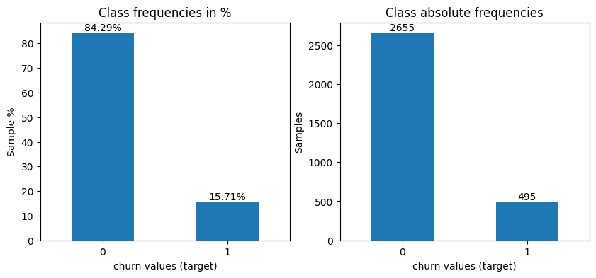

```python
import matplotlib.pyplot as plt


fig, axes = plt.subplots(1, 2, figsize=(10, 4))

class_frequencies = y.value_counts() / y.value_counts().sum() * 100
class_frequencies = class_frequencies.sort_index()

class_frequencies.plot.bar(ax=axes[0], rot=0)
y.value_counts().plot.bar(ax=axes[1], rot=0)

axes[0].set_title("Class frequencies in %")
axes[0].set_xlabel("churn values (target)")
axes[0].set_ylabel("Sample %")

for container in axes[0].containers:
    axes[0].bar_label(container, fmt="%.2f%%")

axes[1].set_title("Class absolute frequencies")
axes[1].set_xlabel("churn values (target)")
axes[1].set_ylabel("Samples")

for container in axes[1].containers:
    axes[1].bar_label(container)
```

```python
from sklearn.model_selection import train_test_split


(
    X_train,
    X_test,
    y_train,
    y_test,
    fn_cost_train,
    fn_cost_test,
    fp_cost_train,
    fp_cost_test,
) = train_test_split(
    df, y, fn_cost, fp_cost, test_size=0.25, random_state=0, stratify=y
)
```

```python
from sklearn.preprocessing import StandardScaler


standard_scaler = StandardScaler()

X_train = pd.DataFrame(standard_scaler.fit_transform(X_train), columns=list(df.columns))
X_test = pd.DataFrame(standard_scaler.transform(X_test), columns=list(df.columns))
```

**Zadanie 6 (1 punkt)**

Wytrenuj liniowy SVM:

- ustaw maksymalnie 10000 iteracji i zbalansowane wagi klas
- dokonaj tuningu hiperparametru `C` za pomocą 5-krotnej walidacji skrośnej
- sprawdź 100 wartości z zakresu od $10^{-2}$ do $10^2$
- wypisz znalezioną optymalną wartość `C`
- wybierz model o najwyższym F1-score
- zmierz czas treningu (włącznie z tuningiem)
- sprawdź F1-score na zbiorze testowym
- pamiętaj o ustawieniu `random_state=0`

```python
from sklearn.model_selection import GridSearchCV
from time import time


data = X_train, y_train, X_test, y_test


def grid_search(data, clf, C_vals, scoring="f1"):
    X_train_scaled, y_train, X_test_scaled, y_test = data

    param_grid = {
        "C": C_vals,
    }

    cv = GridSearchCV(
        estimator=clf,
        param_grid=param_grid,
        scoring=scoring,
        cv=5,
        n_jobs=-1,
        return_train_score=True,
    )

    # Start of tuning in here
    # - run fit with all sets of parameters
    start_time = time()
    cv.fit(X_train_scaled, y_train)
    end_time = time()
    fit_time = end_time - start_time
    # End of tuning in here

    # Call predict on the estimator
    # with the best found parameters
    start_time = time()
    y_pred = cv.predict(X_test_scaled)
    end_time = time()
    pred_time = end_time - start_time

    print(f"Fit time: {fit_time:.2f} s")
    print(f"Prediction time: {pred_time:.2f} s")
    print(f"F1-score: {100 * f1_score(y_test, y_pred):.2f}%")
    print(f"Optimal C value: {cv.best_params_}")

    return cv, y_pred
```

```python
clf_linear_svc = LinearSVC(
    dual=False,
    loss="squared_hinge",
    class_weight="balanced",
    max_iter=10000,
    random_state=0,
)
clf_linear_svc.fit(X_train, y_train)
results = {}
```

```python
C_vals = np.linspace(0.01, 100, 100)
results[1] = grid_search(data, clf_linear_svc, C_vals);
```

```
Fit time: 1.38 s
Prediction time: 0.00 s
F1-score: 61.95%
Optimal C value: {'C': 22.23}
```

**Zadanie 7 (2 punkty)**

1. Wytrenuj kernel SVM z domyślnymi hiperparametrami:
   - ustaw zbalansowane wagi klas
   - zmierz czas treningu
   - sprawdź F1-score na zbiorze testowym
   - zmierz czas treningu
   - pamiętaj o ustawieniu `random_state=0`
2. Wytrenuj kernel SVM z tuningiem hiperparametrów:
   - sprawdź kilka siatek hiperparametrów (`param_grid` może być listą słowników!)
   - dla kerneli RBF sprawdź 10 wartości `C` z zakresu od $10^{-2}$ do $10^2$, a dla `gamma` sprawdź wartość `"scale"` oraz 10 wartości z zakresu od $10^{-2}$ do $10^2$
   - dla kernela wielomianowego sprawdź 100 wartości `C` z zakresu od $10^{-2}$ do $10^2$ oraz stopnie wielomianu z zakresu [2, 5]
   - dla kernela sigmoidalnego sprawdź te same zakresy wartości, co dla RBF
3. Dokonaj analizy hiperparametrów po tuningu:
   - sprawdź, dla jakich hiperparametrów osiągnięto najwyższy wynik walidacji skrośnej
   - sprawdź, jaki był najlepszy wynik osiągnięty dla każdego z trzech kerneli
   - wypisz hiperparametry dla każdego z tych przypadków
   - który kernel wymagał najmocniejszej regularyzacji i jak sądzisz, czemu ten?
   - wytrenuj SVM dla optymalnych hiperparametrów dla każdego z trzech kerneli i sprawdź F1-score na zbiorze testowym
   - czy udało się dobrze oszacować wynik za pomocą walidacji skrośnej, tj. czy faktycznie kernel o najwyższym wyniku walidacyjnym miał najwyższy wynik testowy?

#### Default Kernel SVM

```python
from sklearn.svm import SVC


clf_kernel_svc = SVC(cache_size=512, class_weight="balanced", random_state=0)

start_time = time()
clf_kernel_svc.fit(X_train, y_train)
end_time = time()
fit_time = end_time - start_time

start_time = time()
y_pred = clf_kernel_svc.predict(X_test)
end_time = time()
pred_time = end_time - start_time

print(f"F1-score: {f1_score(y_test, y_pred)*100:.2f}%")
print(f"Training time: {fit_time:.2f} s")
print(f"Prediction time: {pred_time:.2f} s")
```

```
F1-score: 65.71%
Training time: 0.06 s
Prediction time: 0.04 s
```

#### Kernel SVM with hyperparameter tuning

```python
data = X_train, y_train, X_test, y_test


def grid_search_kernel_SVM(data, clf, scoring="f1"):
    X_train, y_train, X_test, y_test = data

    param_grid = [
        {
            "kernel": ["rbf"],
            "C": np.linspace(1e-2, 1e2, 10),
            "gamma": list(["scale"] + list(np.linspace(1e-2, 1e2, 10))),
        },
        {
            "kernel": ["poly"],
            "C": np.linspace(1e-2, 1e2, 100),
            "degree": list(range(2, 6)),
        },
        {
            "kernel": ["sigmoid"],
            "C": np.linspace(1e-2, 1e2, 10),
            "gamma": list(["scale"] + list(np.linspace(1e-2, 1e2, 10))),
        },
    ]

    cv = GridSearchCV(
        estimator=clf,
        param_grid=param_grid,
        scoring=scoring,
        cv=5,
        n_jobs=-1,
        # return_train_score=True,
    )

    # Start of tuning in here
    # - run fit with all sets of parameters
    start_time = time()
    cv.fit(X_train, y_train)
    end_time = time()
    fit_time = end_time - start_time
    # End of tuning in here

    # Call predict on the estimator
    # with the best found parameters
    start_time = time()
    y_pred = cv.predict(X_test)
    end_time = time()
    pred_time = end_time - start_time

    print(f"Fit time: {fit_time:.2f} s")
    print(f"Prediction time: {pred_time:.2f} s")
    print(f"F1-score: {100 * f1_score(y_test, y_pred):.2f}%")

    return cv, y_pred
```

```python
clf_kernel_svc = SVC(cache_size=512, class_weight="balanced", random_state=0)
```

```python
cv, y_pred = grid_search_kernel_SVM([X_train, y_train, X_test, y_test], clf_kernel_svc)
```

```
Fit time: 72.78 s
Prediction time: 0.03 s
F1-score: 84.70%
```

- best hyperparameters set:

```python
# Best grid params of all
cv.best_params_
```

```
{'C': 77.78, 'gamma': 'scale', 'kernel': 'rbf'}
```

```python
# Best mean score for cv splits
cv.best_score_
```

```
0.8353073410927548
```

```python
# Index of the best params set
# just to check something later
cv.best_index_
```

```
77
```

- best score and params for every kernel:

```python
from termcolor import colored


results = pd.DataFrame(cv.cv_results_.copy())
grouped_by_kernel = results.groupby("param_kernel")


def best_params_by_kernel(kernel_key, grouped_df=grouped_by_kernel) -> dict:
    return (
        grouped_df.get_group(kernel_key)
        .sort_values(by="mean_test_score", ascending=False)["params"]
        .head(1)
        .values[0]
    )


def best_scores_by_kernel(kernel_key, grouped_df=grouped_by_kernel) -> float:
    return (
        grouped_df.get_group(kernel_key)
        .sort_values(by="mean_test_score", ascending=False)
        .head(1)["mean_test_score"]
        .values[0]
    )


def print_summary(kernel_key):
    print(colored(f"{'-'*20}{kernel_key.upper()}{'-'*20}", "blue"))
    print(f"Best score: {best_scores_by_kernel(kernel_key)*100:.2f}%")
    print(f"Best score: {best_params_by_kernel(kernel_key)}")


for kernel_key in ["rbf", "poly", "sigmoid"]:
    print_summary(kernel_key)
```

```
--------------------RBF--------------------
Best score: 83.53%
Best score: {'C': 77.78, 'gamma': 'scale', 'kernel': 'rbf'}
--------------------POLY--------------------
Best score: 83.46%
Best score: {'C': 86.87, 'degree': 5, 'kernel': 'poly'}
--------------------SIGMOID--------------------
Best score: 64.24%
Best score: {'C': 11.12, 'gamma': 0.01, 'kernel': 'sigmoid'}
```

C to parametr regularyzacji, który jest odwrotnie proporcjonalny do siły regularyzacji => najmniejsze C to największa siła regularyzacji.  
Najmniejsze C (największą siłę reg.) widzimy dla kernela sigmoidalnego. Sigmoida jest funkcją ograniczoną więc jakoś intuicyjnie spodziewałam się, że wielomianowy kernel będzie potrzebował największej siły regularyzacji, żeby "ściągnąć" w dół za wysokie wartości wielomianów (f. nieograniczone).  
Ale biorąc pod uwagę niski wynik walidacji skrośnej dla sigmoid kernel można pomyśleć, że tzn. że nasze dane nie dają się za dobrze opisać modelem sigmoid kernel, więc też ta siła regularyzacji nie ma tu większego sensu.

- SVM F1-scores:

```python
data = X_train, y_train, X_test, y_test


def fit_predict_svm(data, clf, kernel_key, scoring="f1"):
    X_train, y_train, X_test, y_test = data

    clf.fit(X_train, y_train)
    y_pred = clf.predict(X_test)

    print(
        f"Best cross-validation score: \
    {best_scores_by_kernel(kernel_key)*100:.2f}%"
    )
    print(f"F1-score: {100 * f1_score(y_test, y_pred):.2f}%")

    return y_pred
```

```python
rbf_svc = SVC(
    C=77.78,
    gamma="scale",
    cache_size=512,
    class_weight="balanced",
    random_state=0,
)
fit_predict_svm(data, rbf_svc, "rbf");
```

```
Best cross-validation score:     83.53%
F1-score: 84.70%
```

```python
poly_svc = SVC(
    kernel="poly",
    C=86.87,
    degree=5,
    cache_size=512,
    class_weight="balanced",
    random_state=0,
)
fit_predict_svm(data, poly_svc, "poly");
```

```
Best cross-validation score:     83.46%
F1-score: 82.71%
```

```python
sigmoid_svc = SVC(
    kernel="sigmoid",
    C=11.12,
    gamma=0.01,
    cache_size=512,
    class_weight="balanced",
    random_state=0,
)
fit_predict_svm(data, sigmoid_svc, "sigmoid");
```

```
Best cross-validation score:     64.24%
F1-score: 58.38%
```

// skomentuj tutaj

Za pomocą walidacji skrośnej udało się dobrze oszacować wynik, tj. kernel o najwyższym wyniku walidacyjnym (rbf 83.53%) miał też najwyższy F1-score (rbf 84.70%) na zbiorze testowym. Dobrze też, że wynik na zbiorze testowym przewyższył wynik ze zbioru walidacyjnego. W przypadku poly różnica między tym kernelem a rbf była stosunkowo mała w walidacji skrośnej, ale już widać różnice w F1-score testowym. Dla sigmoidalnego kernela F1-score okazał się dużo niższy od wyniku średniego z walidacji skrośnej, jednak tamten wynik i tak był tak niski, że nie należało się tym kernelem w ogóle sugerować. Generalnie widać, że nasze dane najlepiej opisuje model kernel RBF.

Nie uwzględniliśmy jednak jeszcze faktu, że nasi klienci mają różną wagę. Według badań koszt zyskania klienta jest około 15 razy wyższy od kosztu utrzymania klienta, który jest zagrożony przejściem dla konkurencji. W związku z tym FP i FN mają różną ważnośc. Dodatkowo sami klienci płacą mniej lub więcej, więc to też trzeba uwzględnić. Na szczęście my mamy już to zrobione, bo mamy macierze `fp_cost` oraz `fn_cost` oznaczające koszt pomylenia się na oba sposoby w przypadku każdego klienta.

Powinniśmy zatem używać **ważonej metryki (weighted metric)**, która dla każdego przykładu stosuje odpowiednią wagę, i to w zależności od tego, w jaki sposób się pomyliliśmy. Tego typu metryki typowo działają jak funkcje kosztu - im mniejsza wartość, tym lepiej, bo często dosłownie reprezentują koszt, jaki firma musi ponieść przy stosowaniu danego algorytmu. Wykorzystanie takiej metryki to **cost-sensitive classification**.

**Zadanie 8 (0.5 punktu)**

1. Uzupełnij kod funkcji `churn_cost()`, która oblicza koszt dokonania danej klasyfikacji.
2. Stwórz funkcję w postaci akceptowanej przez `GridSearchCV` za pomocą `make_scorer`. Zwróć uwagę, żeby podać do niej prawidłowe argumenty.

```python
from typing import Union

from sklearn.metrics import make_scorer


def churn_cost(
    y_true: Union[np.ndarray, pd.Series],
    y_pred: Union[np.ndarray, pd.Series],
    fp_cost: Union[np.ndarray, pd.Series],
    fn_cost: Union[np.ndarray, pd.Series],
) -> float:
    # make sure all data is Numpy arrays
    y_true = np.array(y_true)
    y_pred = np.array(y_pred)
    fp_cost = np.array(fp_cost)
    fn_cost = np.array(fn_cost)

    # check which rows are for FP and FN
    fp_rows = np.intersect1d(np.where(y_true == 0), np.where(y_pred == 1))
    fn_rows = np.intersect1d(np.where(y_true == 1), np.where(y_pred == 0))

    # get costs for FP and FN
    fps_sum = np.sum(fp_cost[fp_rows])
    fns_sum = np.sum(fn_cost[fn_rows])

    # return sum of costs
    return fps_sum + fns_sum


churn_cost_score = make_scorer(
    churn_cost,
    greater_is_better=False,
    fp_cost=fp_cost_test,
    fn_cost=fn_cost_test,
)
```

**Zadanie 9 (1 punkt)**

1. Wytrenuj klasyfikatory stały `DummyClassifier`:
   - taki, który zawsze przewiduje klasę negatywną (brak zmiany)
   - taki, który zawsze przewiduje klasę pozytywną (churn)
2. Sprawdź metrykę F1-score oraz nasz nowo zdefiniowany churn cost dla takich rozwiązań na zbiorze testowym. Wykorzystaj `fp_cost_test` oraz `fn_cost_test`.
3. Lepiej jest stosować reklamy dla wszystkich, czy po prostu zgodzić się na churn i nic z tym nie robić? Uwzględniając liczbę próbek w zbiorze testowym, czy twoim zdaniem wysoki koszt? Załóż, że walutą są dolary - irański rial zawsze był tak słabą walutą, że i tak używano walut zagranicznych, co widać też w tym zbiorze. Wartość każdego klienta jest typowo wysoka, bo to obliczona tzw. lifetime value - przewidywana potencjalna wartość klienta w przyszłości.

```python
from sklearn.dummy import DummyClassifier


neg_dummy_clf = DummyClassifier(strategy="constant", random_state=0, constant=0)
pos_dummy_clf = DummyClassifier(strategy="constant", random_state=0, constant=1)

neg_dummy_clf.fit(X_train, y_train)
pos_dummy_clf.fit(X_train, y_train)

neg_dummies_pred = neg_dummy_clf.predict(X_test)
pos_dummies_pred = pos_dummy_clf.predict(X_test)
```

```python
f1_score_neg = f1_score(y_test, neg_dummies_pred)
f1_score_pos = f1_score(y_test, pos_dummies_pred)

print(
    f"Negative (churn=0, everybody stays) \
dummy f1 score: {f1_score_neg*100:.2f}%"
)
print(
    f"Positive (churn=1 everybody leaves) \
dummy f1 score: {f1_score_pos*100:.2f}%"
)
print()

churn_score_neg = churn_cost_score(neg_dummy_clf, X_test, y_test)
churn_score_pos = churn_cost_score(pos_dummy_clf, X_test, y_test)

print(
    f"Negative (churn=0, everybody stays) dummy churn cost score: \
{churn_score_neg:.2f}"
)
print(
    f"Positive (churn=1 everybody leaves) dummy churn cost score: \
{churn_score_pos:.2f}"
)
print()

# greater_is_better=False sign-flips the scorer outcome
print(
    f"Negative (churn=0, everybody stays) dummy \
churn cost score absolute value: {-1*churn_score_neg:.2f}$"
)
print(
    f"Positive (churn=1 everybody leaves) dummy \
churn cost score absolute value: {-1*churn_score_pos:.2f}$"
)
print()

outcome_per_customer = lambda outcome: outcome / X_test.shape[0]
print(
    f"Negative (churn=0, everybody stays) dummy avg \
{outcome_per_customer(-1*churn_score_neg):.2f}$ per customer"
)
print(
    f"Positive (churn=1 everybody leaves) dummy avg \
{outcome_per_customer(-1*churn_score_pos):.2f}$ per customer"
)
```

```
Negative (churn=0, everybody stays) dummy f1 score: 0.00%
Positive (churn=1 everybody leaves) dummy f1 score: 27.19%

Negative (churn=0, everybody stays) dummy churn cost score: -15871.64
Positive (churn=1 everybody leaves) dummy churn cost score: -69593.20

Negative (churn=0, everybody stays) dummy churn cost score absolute value: 15871.64$
Positive (churn=1 everybody leaves) dummy churn cost score absolute value: 69593.20$

Negative (churn=0, everybody stays) dummy avg 20.14$ per customer
Positive (churn=1 everybody leaves) dummy avg 88.32$ per customer
```

// skomentuj tutaj

`Negative (churn=0, everybody stays) dummy avg 20.14$ per customer`  
`Positive (churn=1 everybody leaves) dummy avg 88.32$ per customer`

Z powyższego (wytrenowania stałych klasyfikatorów i obliczenia naszego kosztu) wynika, że ponad 4-krotnie wyższy koszt ponosi się traktując każdego klienta reklamami/promocjami (zał., że odejdzie) niż godząc się na churn każdego klienta bez walki. Co lepiej stosować zależy już chyba od szerszego kontekstu finansowo-marketingowego firmy.

Tak wynika z naszych danych fp_cost_test i fn_cost_test. Natomiast generalnie trening dummy klasyfikatora z arg. constant niespecjalnie wykorzystuje dane ze zbioru treningowego, więc w sumie moglibyśmy powyższe obliczenia zrobić też dla fp_cost_train i fn_cost_train (zamiast dla _test) i podzielić przez wielkość macierzy treningowych. Zobaczmy zatem, co mówi nasz zbiór treningowy o wartościach fp_cost i fn_cost (zawsze jest ich trochę więcej niż testowych...):r

```python
churn_cost_score = make_scorer(
    churn_cost,
    greater_is_better=False,
    fp_cost=fp_cost_train,
    fn_cost=fn_cost_train,
)

churn_score_neg = churn_cost_score(neg_dummy_clf, X_train, y_train)
churn_score_pos = churn_cost_score(pos_dummy_clf, X_train, y_train)

# greater_is_better=False sign-flips the scorer outcome
outcome_per_customer = lambda outcome: outcome / X_train.shape[0]
print(
    f"Negative (churn=0, everybody stays) dummy avg \
{outcome_per_customer(-1*churn_score_neg):.2f}$ per customer"
)
print(
    f"Positive (churn=1 everybody leaves) dummy avg \
{outcome_per_customer(-1*churn_score_pos):.2f}$ per customer"
)
```

```
Negative (churn=0, everybody stays) dummy avg 16.82$ per customer
Positive (churn=1 everybody leaves) dummy avg 87.88$ per customer
```

Dane fn_cost i fp_cost ze zbioru treningowego pokazują podobną sytuację, dane ze zbioru testowego przewidywały trochę wyższe koszta dla przypadku negatywnego (churn = 0).

**Zadanie 10 (1.5 punktu)**

1. Wytrenuj liniowy SVM, wykorzystaj znalezioną wcześniej optymalną wartość `C`. Innych parametrów użyj tak, jak wcześniej. Jaki jest koszt przy wdrożeniu takiego rozwiązania? Ile zyskujemy względem najlepszego rozwiązania z poprzedniego zadania?
2. Wytrenuj kernel SVM, wykorzystaj znalezione wcześniej optymalne wartości hiperparametrów. Innych parametrów użyj tak, jak wcześniej. O ile lepszy jest koszt? O ile lepszy jest od modelu liniowego, jakim jest liniowy SVM?
3. Czy twoim zdaniem warto wdrażać rozwiązania oparte o ML do takich zadań?

#### Linear SVM

```python
churn_cost_score = make_scorer(
    churn_cost,
    greater_is_better=False,
    fp_cost=fp_cost_test,
    fn_cost=fn_cost_test,
)
```

```python
clf_linear_svc = LinearSVC(
    dual=False,
    loss="squared_hinge",
    class_weight="balanced",
    C=22.23,
    max_iter=10000,
    random_state=0,
)
clf_linear_svc.fit(X_train, y_train);
```

```python
def get_f1_score_and_churn_cost(
    clf, X_test, y_test, fp_cost_train=fp_cost_train, fn_cost_train=fn_cost_train
):
    y_pred = clf.predict(X_test)

    f1score = f1_score(y_test, y_pred)
    print(f"f1 score: {f1score*100:.2f}%")
    churn_score = churn_cost_score(clf, X_test, y_test)
    print(f"Churn cost score: {churn_score:.2f}")
    print(f"Churn cost score absolute value: {-1*churn_score:.2f}$")
    outcome_per_customer = lambda outcome: outcome / X_test.shape[0]
    print(f"Avg {outcome_per_customer(-1*churn_score):.2f}$ per customer")
```

```python
get_f1_score_and_churn_cost(clf_linear_svc, X_test, y_test)
```

```
f1 score: 61.95%
Churn cost score: -11266.07
Churn cost score absolute value: 11266.07$
Avg 14.30$ per customer
```

#### Kernel SVM

```python
rbf_svc = SVC(
    C=77.78,
    gamma="scale",
    cache_size=512,
    class_weight="balanced",
    random_state=0,
)
rbf_svc.fit(X_train, y_train);
```

```python
get_f1_score_and_churn_cost(rbf_svc, X_test, y_test)
```

```
f1 score: 84.70%
Churn cost score: -3547.27
Churn cost score absolute value: 3547.27$
Avg 4.50$ per customer
```

// skomentuj tutaj

1. Churn cost dla liniowego SVM z wybranymi wcześniej hiperparametrami wynosi 14.30 dolar per customer. To rozwiązanie korzystniejsze od bierności względem klienta (zakładania, że churn każdego klienta to 0) (Negative dummy classifier z poprzedniego zadania miał churn cost 20.14 dolar per customer), i też korzystniejsze na pewno od stosowania reklam względem każdego klienta (Positive dummy classifier miał 88.32 dolar per customer).
2. Przy Kernel SVM widzimy wyraźną korzyść względem poprzednich modeli, churn cost wyniósł tu 4.50 dolar per customer -> to dobry wynik. Pokazuje nam to taką namacalną różnicę między wynikami modeli, którą może widać w f1-score, ale dolary są jednak namacalne :).
3. Jak widać niekoniecznie każdy model dobrze opisze nasze dane i faktycznie coś z niego realnie będzie, ale zastosowane liczenie funkcji kosztu churn chociażby dobrze obrazuje sytuację pod kątem kampanii marketingowej i świadomości problemu.

## Zadanie dodatkowe (3 punkty)

W przypadku, kiedy zastosowanie kernel SVM wprost byłoby zbyt kosztowne, można zamiast tego przybliżyć cechy kernelowe. Realizują to algorytmy grupy kernel approximation.

Metoda Nyströma to algorytm uniwersalny, który potrafi przybliżyć dowolny kernel. Wykorzystuje do tego truncated SVD, czyli przybliża wprost kernel matrix za pomocą macierzy niższej rangi. Ceną tej prostoty i uniwersalności jest nie najlepsza prędkość działania w porównaniu do bardziej specjalistycznych algorytmów. Proste wyprowadzenie tej metody można znaleźć [tutaj](https://stats.stackexchange.com/questions/261149/nystroem-method-for-kernel-approximation).

`RBFSampler` w Scikit-learn implementuje metodę Random Kitchen Sinks. Ten algorytm za pomocą próbkowania Monte Carlo przybliża coraz lepiej macierz kernela RBF. W bibliotece Scikit-learn-extra zaimplementowane jest rozwinięcie tego algorytmu o nazwie [Fastfood](https://scikit-learn-extra.readthedocs.io/en/stable/generated/sklearn_extra.kernel_approximation.Fastfood.html), który stosuje nieco bardziej zaawansowany algorytm przybliżający, który powinien być jeszcze szybszy i oszczędniejszy pamięciowo.

Hiperparametry tych metod są podobne do zwykłego kernel SVM, ale dodatkowo mamy wymiarowość naszego przybliżenia, czyli `n_components`. Im większe, tym dokładniej przybliżamy, ale też tym więcej mamy cech. Wejściem do metody Nyströma jest macierz cech X, a wyjściem macierz cech kernelowych X mająca rozmiar `n_samples * n_components`. Na takich cechach trenuje się już zwykły liniowy SVM.

1. Zaimplementuj `Pipeline` składający się z przybliżenia kernela oraz liniowego SVM: dla metody Nyströma, oraz dla obu algorytmów dla kernela RBF.
2. Wytrenuj algorytmy z domyślnymi hiperparametrami dla zbioru Cod-RNA. Porównaj jakość predykcji oraz szybkość z liniowym SVM i kernel SVM. Czy warto wykorzystać takie podejście?
3. Dokonaj optymalizacji hiperparametrów `C`, `gamma` oraz `n_components`. Czy udało się poprawić wynik względem zwykłego kernel SVM w rozsądnym czasie?